# MacroSheds data retrieval and flux calculation

# Retrieve discharge data for target sites

```r
my_ms_dir <- './example/data'
```

##### ms_download_core_data

```r
?ms_download_core_data
```

Now, we retrieve MacroSheds data by domain and save it to our new `macrosheds_root` directory. This same directory should be used when downloading watershed attribute data via `ms_download_ws_attr`, and it *must* be used to load data via `ms_load_product`. You can download all core data with `domains = 'all'`

```r
options(timeout = 600) #default 60 might not be enough if your connection is slow

ms_download_core_data(
    macrosheds_root = my_ms_dir,
    domains = my_domains,
    quiet = FALSE
)
```

##### ms_load_product *discharge*

Now we have the data downloaded, but we want to load specific variables into the R session. To do this, we use `ms_load_product`.

```r
?ms_load_product
```

Pointing to the directory we downloaded the data to, we use this function to pull out discharge data for two sites.

```r
my_q <- ms_load_product(
    my_ms_dir,
    prodname = 'discharge',
    site_codes = c('w7', 'GSWS07')
)
```

# Retrieve stream chemistry data for target sites

#### ms_load_product *chemistry*

Now that we have discharge, we will use `ms_load_product` again, but for nitrate-N data. As we know from searching the variable catalog, the code for nitrate-N is ‘NO3_N’

```r
my_chem <- ms_load_product(
    my_ms_dir,
    prodname = 'stream_chemistry',
    filter_vars = 'NO3_N',
    site_codes = c('w7', 'GSWS07')
)

head(my_chem)
```

| datetime | site_code | var | val | ms_status | ms_interp | val_err |
| --- | --- | --- | --- | --- | --- | --- |
| 1974-07-16 | w7 | GN_NO3_N | 0.0609921 | 0 | 0 | 0 |
| 1974-07-17 | w7 | GN_NO3_N | 0.0593786 | 0 | 1 | 0 |
| 1974-07-18 | w7 | GN_NO3_N | 0.0577650 | 0 | 1 | 0 |
| 1974-07-19 | w7 | GN_NO3_N | 0.0561515 | 0 | 1 | 0 |
| 1974-07-20 | w7 | GN_NO3_N | 0.0545379 | 0 | 1 | 0 |
| 1974-07-21 | w7 | GN_NO3_N | 0.0529244 | 0 | 1 | 0 |

# Calculate daily flux*

*see `ms_calc_flux_rsfme` for calculating cumulative monthly/annual flux (in development at the time of this writing)

#### ms_calc_flux

Use `ms_calc_flux` to calculate daily nitrate-N flux from discharge and concentration datasets.

```r
?ms_calc_flux
```

We can plug in our discharge and chemistry data directly.

```r
my_flux <- ms_calc_flux(
    chemistry = my_chem,
    q = my_q,
    q_type = 'discharge'
)
```

```
## [1] "q dataset has a daily interval"
```

```r
head(my_flux)
```

| datetime | site_code | var | val | ms_status | ms_interp | val_err |
| --- | --- | --- | --- | --- | --- | --- |
| 1974-07-16 | w7 | GN_NO3_N | 0.0012090 | 0 | 0 | 0.0001107 |
| 1974-07-17 | w7 | GN_NO3_N | 0.0006615 | 0 | 1 | 0.0000438 |
| 1974-07-18 | w7 | GN_NO3_N | 0.0004398 | 0 | 1 | 0.0000192 |
| 1974-07-19 | w7 | GN_NO3_N | 0.0003581 | 0 | 1 | 0.0000140 |
| 1974-07-20 | w7 | GN_NO3_N | 0.0005722 | 0 | 1 | 0.0000159 |
| 1974-07-21 | w7 | GN_NO3_N | 0.0003973 | 0 | 1 | 0.0000202 |

From the documentation of `ms_calc_flux` we can see that flux units are `kg/ha/T`, where T is the sampling interval. This is desirable because we are comparing between two very different watersheds and it is usually appropriate to scale by their areas. If you’re interested in the unscaled flux, see ‘ms_undo_scale_flux_by_area’.

#### ms_synchronize_timestep

Macrosheds core time-series data are interpolated like so: + discharge: linear interpolation, gaps of up to 3 days + stream chemistry: linear interpolation, gaps of up to 15 days + precipitation chemistry (concentration): next-observation-carried-backward, gaps of up to 45 days + precipitation depth: 0-interpolation (unless special case), gaps of up to 45 days

```r
my_chem2 <- ms_synchronize_timestep(
    my_chem,
    desired_interval = '1 day',
    interpolate_limit = 40
)
my_flux2 <- ms_calc_flux(
    chemistry = my_chem2,
    q = my_q,
    q_type = 'discharge'
)
```

```
## [1] "q dataset has a daily interval"
```

```r
head(my_flux)
```

| datetime | site_code | var | val | ms_status | ms_interp | val_err |
| --- | --- | --- | --- | --- | --- | --- |
| 1974-07-16 | w7 | GN_NO3_N | 0.0012090 | 0 | 0 | 0.0001107 |
| 1974-07-17 | w7 | GN_NO3_N | 0.0006615 | 0 | 1 | 0.0000438 |
| 1974-07-18 | w7 | GN_NO3_N | 0.0004398 | 0 | 1 | 0.0000192 |
| 1974-07-19 | w7 | GN_NO3_N | 0.0003581 | 0 | 1 | 0.0000140 |
| 1974-07-20 | w7 | GN_NO3_N | 0.0005722 | 0 | 1 | 0.0000159 |
| 1974-07-21 | w7 | GN_NO3_N | 0.0003973 | 0 | 1 | 0.0000202 |

# Results

Note: `macrosheds::ms_calc_flux_rsfme` will produce much more robust monthly and annual flux estimates. This function is in development, so check back.

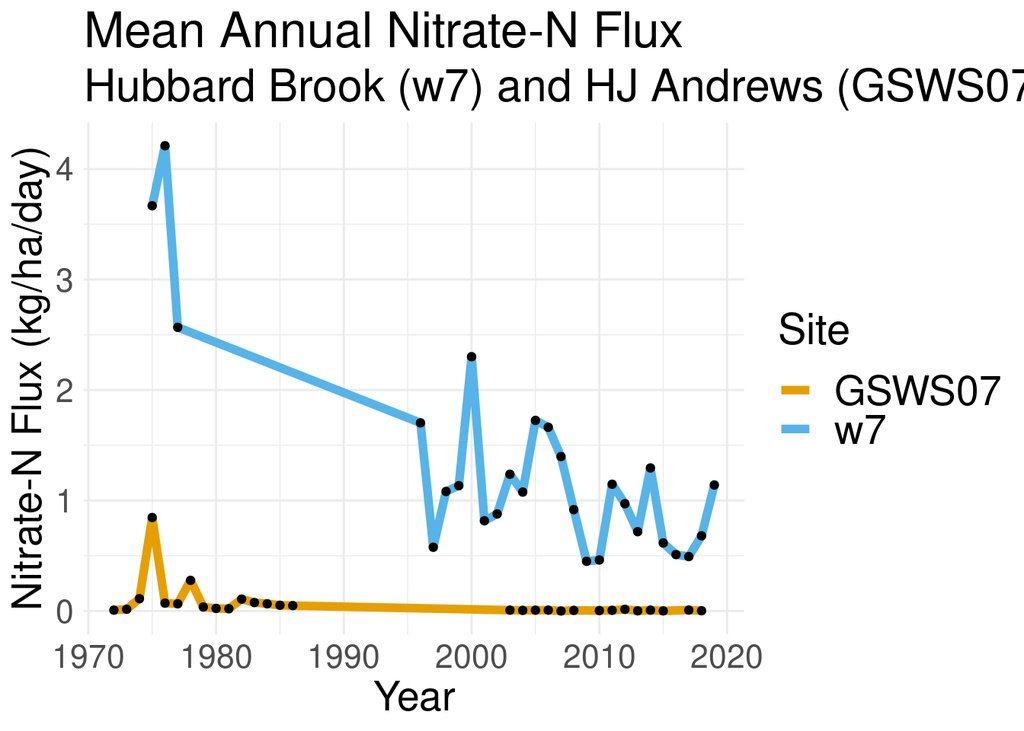

```r
my_annual_mean_flux <- my_flux2 %>%
    mutate(year = as.numeric(format(as.Date(datetime), format='%Y'))) %>%
    group_by(year, site_code) %>%
    summarize(
        mean_flux = sum(val, na.rm = TRUE),
        n = n(),
        .groups = 'drop',
    ) %>%
    filter(n > 330)

ggplot(data=my_annual_mean_flux, aes(x=year, y=mean_flux, group=site_code)) +
    geom_line(aes(color=site_code), lwd = 2)+
    geom_point() +
    scale_color_manual(
      values=c('#E69F00', '#56B4E9'),
      name = 'Site'
    ) +
    ggtitle(
      label = 'Mean Annual Nitrate-N Flux',
      subtitle = 'Hubbard Brook (w7) and HJ Andrews (GSWS07), 1970-2020'
    ) +
    xlab('Year') +
    ylab('Nitrate-N Flux (kg/ha/day)') +
    theme_minimal() +
    theme(
      axis.text = element_text(size = 16),
      axis.title = element_text(size = 20),
      plot.title = element_text(size = 24),
      plot.subtitle = element_text(size = 22),
      legend.title = element_text(size = 21),
      legend.text = element_text(size = 20),
    )
```